```r
library(readr)
library(dplyr)
library(ggplot2)
big5_data_by_team <- read_csv("../data/dataset/big5_data_by_teams/big5_data_by_team.csv",show_col_types = FALSE)
```

On va sélectionner les colonnes qui nous intéressent pour notre analyse. Dans notre cas on va sélectionner les données de 2022 et les données concernant les 5 meilleures équipes de la première League pour cette année, à savoir Manchester City, Liverpool, Chelsea, Tottenham, Arsenal. On va également rajouter une équipe plus basse dans le classement, Southampton, ainsi qu’une équipe moyenne, Newcastle afin d’éventuellement noter des différences entre le top 5 et des équipes moins bien classés.

Les colonnes concernées sont”Season_End_Year” et “Squad”

```r
big5_data_by_team <- big5_data_by_team %>% filter(Season_End_Year == 2022 & Squad %in% c("Manchester City", "Liverpool", "Chelsea", "Tottenham", "Arsenal", "Newcastle Utd", "Southampton"))
```

```r
big5_data_by_team <- big5_data_by_team %>% select(Squad, Team_or_Opponent, Gls, "_percent_Pressures", Touches_Touches, Succ_percent_Dribbles)
```

On va ensuite renommer les colonnes pour plus de clarté

```r
big5_data_by_team <- big5_data_by_team %>% rename(Equipe = Squad, Buts = Gls, Reussite_pressing = '_percent_Pressures', Touches = Touches_Touches, Reussite_Dribble = Succ_percent_Dribbles)
```

```r
big5_data_by_team <- big5_data_by_team %>% group_by(Equipe) %>% summarise(Buts = sum(Buts), Reussite_pressing = mean(Reussite_pressing), Touches = mean(Touches), Reussite_Dribble = mean(Reussite_Dribble))
```

Avant de faire des visualisations, on va ordonner les lignes en fonction des positions des 5 premières équipes dans le classement de la ligue, à savoir Manchester City, Liverpool, Chelsea, Tottenham, Arsenal On va ensuite rajouter une équipe moins bonne dans le classement, pour voir si ces paramètres sont plus déterminants pour différencier les équipes de bas niveau. On va rajouter l’équipe de Southampton, qui est 15ème de la ligue, et donc une équipe de bas niveau. On va également rajouter l’équipe de Newcastle, qui est 11ème de la ligue, et donc une équipe de milieu de tableau.

```r
big5_data_by_team <- big5_data_by_team %>% mutate(Equipe = factor(Equipe, levels = c("Manchester City", "Liverpool", "Chelsea", "Tottenham", "Arsenal","Newcastle Utd", "Southampton")))
```

On peut ensuite faire une première visualisation, avec un barplot qui affiche le nombre de but marqué par chaque équipe.

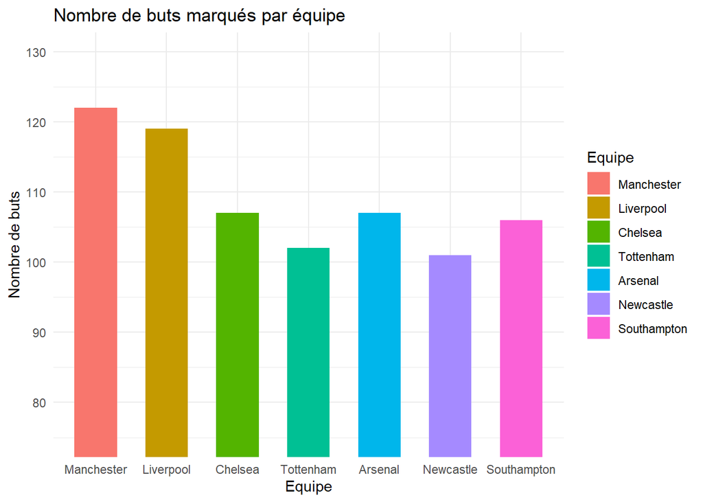

```r
big5_data_by_team <- big5_data_by_team %>%
  mutate(Equipe = recode(Equipe, "Manchester City" = "Manchester",
                                   "Newcastle Utd" ="Newcastle"))
ggplot(big5_data_by_team, aes(x = Equipe, y = Buts, fill = Equipe)) +
  geom_bar(stat = "identity", width = 0.6) +
  theme_minimal() +
  labs(title = "Nombre de buts marqués par équipe", x = "Equipe", y = "Nombre de buts")+
  coord_cartesian(ylim = c(75,130))
```

[figure not shown]

```r
ggplot(big5_data_by_team, aes(x = Equipe, y = Reussite_pressing, fill = Equipe)) + geom_bar(stat = "identity") + theme_minimal() + labs(title = "Pourcentage de pressing réussis par équipe", x = "Equipe", y = "Pourcentage de pressing réussis")+  theme(axis.text.x = element_text(angle = 90, vjust = 0.5, hjust = 1))+
  guides(fill = guide_legend(ncol = 2))
```

[figure not shown]

```r
ggplot(big5_data_by_team, aes(x = Equipe, y = Touches, fill = Equipe)) + geom_bar(stat = "identity") + theme_minimal() + labs(title = "Nombre de touches par équipe", x = "Equipe", y = "Nombre de touches")+coord_cartesian(ylim = c(40000,50000))+  theme(axis.text.x = element_text(angle = 90, vjust = 0.5, hjust = 1))+
  guides(fill = guide_legend(ncol = 2))
```

[figure not shown]

```r
ggplot(big5_data_by_team, aes(x = Equipe, y = Reussite_Dribble, fill = Equipe)) + geom_bar(stat = "identity") + theme_minimal() + labs(title = "Pourcentage de dribbles réussis par équipe", x = "Equipe", y = "Pourcentage de dribbles réussis")+  theme(axis.text.x = element_text(angle = 90, vjust = 0.5, hjust = 1))+
  guides(fill = guide_legend(ncol = 2))
```

On constate qu’il n’y a finalement que très peu de différence entre les équipes pour ces paramètres. On peut donc en conclure que ces paramètres ne sont pas déterminants pour différencier les équipes entre elles. Cela peut s’expliquer par le fait que les équipes de haut niveau ont des joueurs de qualité, et que ces paramètres sont donc assez homogènes entre les équipes de haut niveau.

On constate finalement que deux paramètres semblent être lié à la position des équipes dans la ligue : le nombre de but, et le nombre de touches. Pour les autres, il est possible que le fait que ce sont des pourcentages de réussites ne permettent pas d’identifier une corrélation, on peut éventuellement s’intéresser au nombre de dribbles et de pressing reussis, et non pas aux pourcentages de réussite.

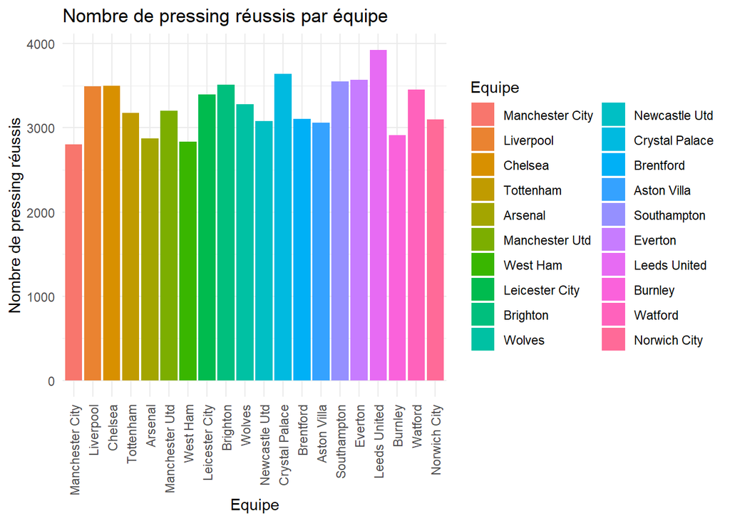

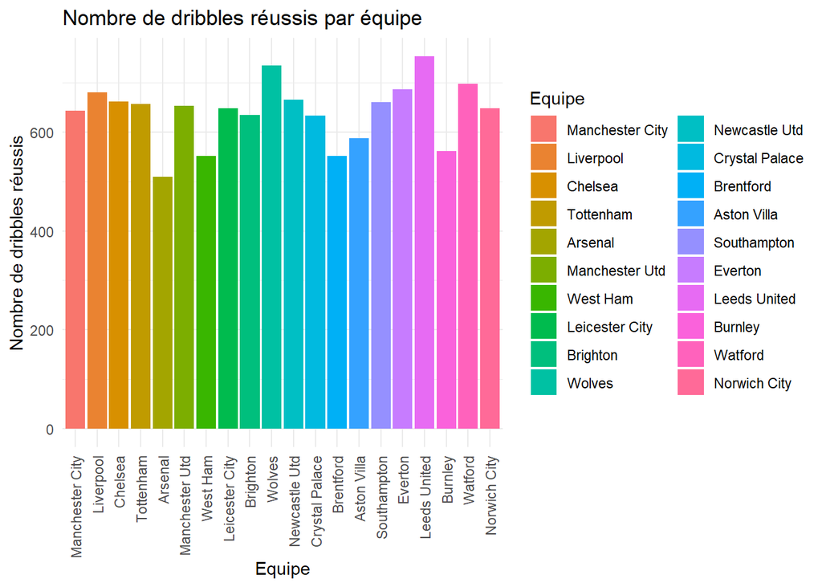

À nouveau, on ne constate aucun lien particulier entre ces paramètres et la position des équipes dans la ligue. On peut donc en conclure que le nombre de buts et le nombre de touches sont les paramètres les plus importants pour différencier les équipes entre elles.

On peut maintenant se demander si pour d’autres championnat, comme la Ligue 1, le nombre de buts et le nombres de touches sont également les paramètres les plus importants. On effectue donc la même analyse, mais avec toutes les équipes de la ligue 1 On ne va regarder que le nombre de buts et le nombre de touches.

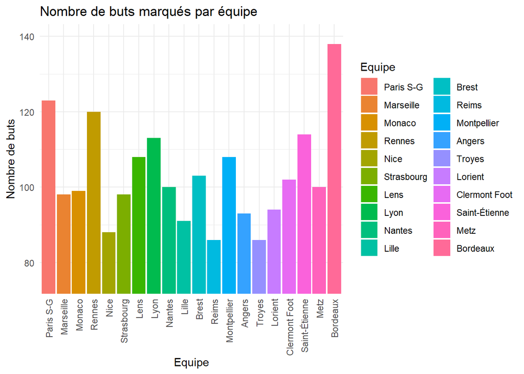

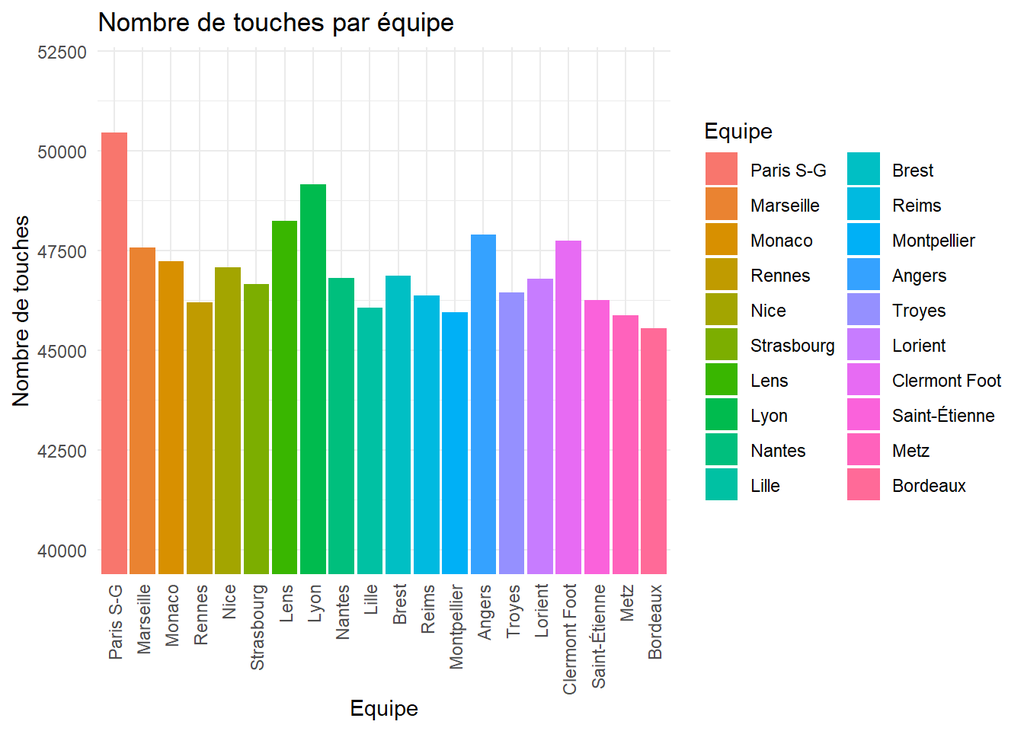

On constate que les résultats ne sont pas vraiment similaires à ce que l’on pouvait retrouver pour la Premiere League. En effet, on constate que le nombre de but ne semble pas réellement dépendre du classement des équipes, et on remarque également que le nombre de touche est relativement similaires à l’exception de quelques équipes. On en conclut donc que les meilleures équipes de championnat se démarque dans des caractéristiques différentes en fonction du champinnat concerné.

#### Conclusion sur la première question

Pour conclure sur cette première question, nous pouvons dire qu’en ce qui concerne la première ligue, les deux paramètres qui semblent être déterminant pour différencier une équipe en haut du tableau et une équipe en bas du tableau sont le nombre de buts marqués et le nombre de touches.

Cependant, nous avons aussi pu remarquer que beaucoup de caractéristiques qui semblaient être pertinentes pour différencier les meilleures équipes des moins bonnes ne peuvent en réalité pas être réellement exploitées.

Cela nous amène donc à penser qu’au delà du nombre de buts et de touches, c’est surtout le cumul d’une multitude d’actions faites par les joueurs durant un match, des actions qui sont difficilement représentables par des chiffres, et qui sont pourtant décisives pour différencier une équipe d’une autre.